# Preprocessing

## Loading of documents (years 2010 - 2020)

```r
NA_values <- c("", '9999', '999', '99999')
selected_cols <- c('STATION', 'DATE', 'TMP', 'WND_ANGLE', 'WND_SPEED', 'VIS', 'SLP', 'CIG', 'DEW', 'LATITUDE', 'LONGITUDE', 'ELEVATION', 'NAME')


allfiles <- list.files(path = "../data", pattern = "*.csv", full.names = T)

data_sliac <- data.table::rbindlist(lapply(allfiles, function(x) cbind(fread(x, fill = T), gsub(".csv", "", x))), fill = T)

data_sliac <- as.data.frame(data_sliac)
```

```r
mandatory_data <- data_sliac %>%
  separate(TMP, c('TMP', NA), sep=',')  %>%
  separate(WND, c('WND_ANGLE', NA, NA, 'WND_SPEED', NA)) %>%
  separate(VIS, c('VIS', NA, NA, NA)) %>%
  separate(SLP, c('SLP', NA)) %>%
  separate(CIG, c('CIG', NA, NA, NA)) %>%
  separate(DEW, c('DEW', NA), sep=',') %>%
  dplyr::mutate(
    TMP = map_dbl(.$TMP,  replace_NA, 10),
    WND_ANGLE = map_dbl(.$WND_ANGLE, replace_NA),
    WND_SPEED = map_dbl(.$WND_SPEED, replace_NA, 10),
    VIS = map_dbl(.$VIS, replace_NA),
    SLP = map_dbl(.$SLP, replace_NA, 10),
    CIG = map_dbl(.$CIG, replace_NA),
    DEW = map_dbl(.$DEW, replace_NA, 10)
  ) %>%
  dplyr::select(all_of(selected_cols))

View(mandatory_data)
```

# Repalcing Na

```r
replace_NA <- function(val, scaling = 1) {
  if (is.na(val) || val %in% NA_values){
    return (NA)
  }
  else {
    return (as.numeric(val)/scaling)
  }
}
```

### Firstly we must have a look at temperature

According to isd documentation, under TMP field there are two information. AIR-TEMPERATURE-OBSERVATION air temperature which concerns us and should be numeric, with sign prefix. If any value is missing 9999 represents it. It is scaled up tenfold.

Similarly we need to process other attributes: Wind, Visibility, Pressure, Ceiling and Dew.

# AIR-TEMPERATURE-OBSERVATION dew point temperature

The temperature to which a given parcel of air must be cooled at constant pressure and water vapor content in order for saturation to occur.

MIN: -0982 MAX: +0368 UNITS: Degrees Celsius SCALING FACTOR: 10 DOM: A general domain comprised of the numeric characters (0-9), a plus sign (+), and a minus sign (-).

+9999 = Missing.

### Exploratory data analysis

Firstly we look at data structure(str) which gives us information about number of observations(rows) and columns, column names and types and a head of the first observations. Secondly we look at the data summary - numbers of zeros, missing values, infinite numbers and unique values.

```r
str(mandatory_data)
```

```
## 'data.frame':    202850 obs. of  13 variables:
##  $ STATION  :integer64 11927599999 11927599999 11927599999 11927599999 11927599999 11927599999 11927599999 11927599999 ...
##  $ DATE     : POSIXct, format: "2010-01-01 00:00:00" "2010-01-01 00:00:00" ...
##  $ TMP      : num  0.5 1 0 0 0.5 1 1 1 0.6 1 ...
##  $ WND_ANGLE: num  NA NA 230 90 NA NA 300 NA NA NA ...
##  $ WND_SPEED: num  0 0 1 0.5 0 0 0.5 0 0 0 ...
##  $ VIS      : num  800 800 1500 800 500 500 500 500 500 500 ...
##  $ SLP      : num  996 NA NA NA 993 ...
##  $ CIG      : num  120 120 690 120 90 90 90 90 90 90 ...
##  $ DEW      : num  0.5 0 0 0 0.5 0 0 0 0.6 1 ...
##  $ LATITUDE : num  48.6 48.6 48.6 48.6 48.6 ...
##  $ LONGITUDE: num  19.1 19.1 19.1 19.1 19.1 ...
##  $ ELEVATION: num  318 318 318 318 318 ...
##  $ NAME     : chr  "SLIAC, LO" "SLIAC, LO" "SLIAC, LO" "SLIAC, LO" ...
```

```r
glimpse(mandatory_data)
```

```
## Rows: 202,850
## Columns: 13
## $ STATION   <int64> 11927599999, 11927599999, 11927599999, 11927599999, 119275~
## $ DATE      <dttm> 2010-01-01 00:00:00, 2010-01-01 00:00:00, 2010-01-01 01:00:~
## $ TMP       <dbl> 0.5, 1.0, 0.0, 0.0, 0.5, 1.0, 1.0, 1.0, 0.6, 1.0, 1.0, 1.0, ~
## $ WND_ANGLE <dbl> NA, NA, 230, 90, NA, NA, 300, NA, NA, NA, NA, 250, NA, NA, N~
## $ WND_SPEED <dbl> 0.0, 0.0, 1.0, 0.5, 0.0, 0.0, 0.5, 0.0, 0.0, 0.0, 0.5, 1.5, ~
## $ VIS       <dbl> 800, 800, 1500, 800, 500, 500, 500, 500, 500, 500, 400, 500,~
## $ SLP       <dbl> 995.5, NA, NA, NA, 993.2, NA, NA, NA, 991.8, NA, NA, NA, 991~
## $ CIG       <dbl> 120, 120, 690, 120, 90, 90, 90, 90, 90, 90, 90, 900, 120, 90~
## $ DEW       <dbl> 0.5, 0.0, 0.0, 0.0, 0.5, 0.0, 0.0, 0.0, 0.6, 1.0, 1.0, 1.0, ~
## $ LATITUDE  <dbl> 48.63784, 48.63784, 48.63784, 48.63784, 48.63784, 48.63784, ~
## $ LONGITUDE <dbl> 19.13411, 19.13411, 19.13411, 19.13411, 19.13411, 19.13411, ~
## $ ELEVATION <dbl> 317.9, 317.9, 317.9, 317.9, 317.9, 317.9, 317.9, 317.9, 317.~
## $ NAME      <chr> "SLIAC, LO", "SLIAC, LO", "SLIAC, LO", "SLIAC, LO", "SLIAC, ~
```

```r
status(mandatory_data)
```

```
##            variable q_zeros      p_zeros   q_na      p_na q_inf p_inf
## STATION     STATION       0 0.000000e+00      0 0.0000000     0     0
## DATE           DATE       0 0.000000e+00      0 0.0000000     0     0
## TMP             TMP    4091 2.016761e-02      0 0.0000000     0     0
## WND_ANGLE WND_ANGLE       0 0.000000e+00 106370 0.5243776     0     0
## WND_SPEED WND_SPEED   32345 1.594528e-01  17149 0.0845403     0     0
## VIS             VIS      29 1.429628e-04      0 0.0000000     0     0
## SLP             SLP       0 0.000000e+00 120723 0.5951343     0     0
## CIG             CIG       1 4.929751e-06  72465 0.3572344     0     0
## DEW             DEW    6370 3.140251e-02      0 0.0000000     0     0
## LATITUDE   LATITUDE       0 0.000000e+00      0 0.0000000     0     0
## LONGITUDE LONGITUDE       0 0.000000e+00      0 0.0000000     0     0
## ELEVATION ELEVATION       0 0.000000e+00      0 0.0000000     0     0
## NAME           NAME       0 0.000000e+00      0 0.0000000     0     0
##                     type unique
## STATION        integer64      2
## DATE      POSIXct/POSIXt 146356
## TMP              numeric    573
## WND_ANGLE        numeric     36
## WND_SPEED        numeric     46
## VIS              numeric     96
## SLP              numeric    629
## CIG              numeric    195
## DEW              numeric    433
## LATITUDE         numeric      2
## LONGITUDE        numeric      2
## ELEVATION        numeric      2
## NAME           character      1
```

```r
summary(mandatory_data)
```

```
##     STATION                 DATE                          TMP
##  Min.   :11903099999   Min.   :2010-01-01 00:00:00   Min.   :-25.000
##  1st Qu.:11927599999   1st Qu.:2012-10-25 18:37:30   1st Qu.:  2.900
##  Median :11927599999   Median :2014-10-09 10:15:00   Median : 10.000
##  Mean   :11924529074   Mean   :2014-11-22 00:11:13   Mean   :  9.921
##  3rd Qu.:11927599999   3rd Qu.:2016-09-14 23:00:00   3rd Qu.: 17.000
##  Max.   :11927599999   Max.   :2020-12-31 23:00:00   Max.   :999.900
##
##    WND_ANGLE        WND_SPEED           VIS              SLP
##  Min.   : 10.0    Min.   : 0.000   Min.   :     0   Min.   : 975
##  1st Qu.: 60.0    1st Qu.: 0.500   1st Qu.:  9900   1st Qu.:1012
##  Median :200.0    Median : 1.000   Median : 10000   Median :1017
##  Mean   :184.2    Mean   : 1.833   Mean   :138776   Mean   :1017
##  3rd Qu.:290.0    3rd Qu.: 2.600   3rd Qu.: 25000   3rd Qu.:1022
##  Max.   :360.0    Max.   :16.000   Max.   :999999   Max.   :1048
##  NA's   :106370   NA's   :17149                     NA's   :120723
##       CIG             DEW             LATITUDE       LONGITUDE
##  Min.   :    0   Min.   :-28.000   Min.   :48.64   Min.   :19.13
##  1st Qu.:  660   1st Qu.: -0.300   1st Qu.:48.64   1st Qu.:19.13
##  Median : 1463   Median :  5.500   Median :48.64   Median :19.13
##  Mean   : 5935   Mean   :  5.028   Mean   :48.64   Mean   :19.14
##  3rd Qu.: 4200   3rd Qu.: 11.000   3rd Qu.:48.64   3rd Qu.:19.13
##  Max.   :22000   Max.   :999.900   Max.   :48.65   Max.   :19.15
##  NA's   :72465
##    ELEVATION         NAME
##  Min.   :315.0   Length:202850
##  1st Qu.:317.9   Class :character
##  Median :317.9   Mode  :character
##  Mean   :317.5
##  3rd Qu.:317.9
##  Max.   :317.9
##
```

```r
describe(mandatory_data)
```

```
## mandatory_data
##
##  13  Variables      202850  Observations
## --------------------------------------------------------------------------------
## STATION
##          n    missing   distinct       Info       Mean        Gmd
##     202850          0          2      0.329  1.192e+10 2.654e-317
##
## Value      5.880913e-314 5.893017e-314
## Frequency          25426        177424
## Proportion         0.125         0.875
## --------------------------------------------------------------------------------
## DATE
##                   n             missing            distinct                Info
##              202850                   0              146356                   1
##                Mean                 Gmd                 .05                 .10
## 2014-11-22 00:11:13            95930313 2010-10-08 10:27:00 2011-05-09 02:54:00
##                 .25                 .50                 .75                 .90
## 2012-10-25 18:37:30 2014-10-09 10:15:00 2016-09-14 23:00:00 2018-09-03 14:06:00
##                 .95
## 2019-11-03 04:33:00
##
## lowest : 2010-01-01 00:00:00 2010-01-01 01:00:00 2010-01-01 02:00:00 2010-01-01 03:00:00 2010-01-01 04:00:00
## highest: 2020-12-31 19:00:00 2020-12-31 20:00:00 2020-12-31 21:00:00 2020-12-31 22:00:00 2020-12-31 23:00:00
## --------------------------------------------------------------------------------
## TMP
##        n  missing distinct     Info     Mean      Gmd      .05      .10
##   202850        0      573        1    9.921    10.93     -5.0     -2.0
##      .25      .50      .75      .90      .95
##      2.9     10.0     17.0     22.6     26.0
##
## lowest : -25.0 -24.0 -23.0 -22.0 -21.0, highest:  36.8  36.9  37.0  37.3 999.9
##
## Value        -30   -20   -10     0    10    20    30    40  1000
## Frequency      5   690 10548 53942 76039 48517 13008    98     3
## Proportion 0.000 0.003 0.052 0.266 0.375 0.239 0.064 0.000 0.000
##
## For the frequency table, variable is rounded to the nearest 10
## --------------------------------------------------------------------------------
## WND_ANGLE
```

[output cut: 70 more lines]

```
##        n  missing distinct     Info     Mean      Gmd
##   202850        0        2    0.329    317.5   0.6359
##
## Value       315.0  317.9
## Frequency   25426 177424
## Proportion  0.125  0.875
## --------------------------------------------------------------------------------
## NAME
##         n   missing  distinct     value
##    202850         0         1 SLIAC, LO
##
## Value      SLIAC, LO
## Frequency     202850
## Proportion         1
## --------------------------------------------------------------------------------
```

### Analyzing numerical variables

```r
profiling_num(mandatory_data) %>% select(variable, mean, std_dev, range_98)
```

```
##     variable         mean      std_dev           range_98
## 1        TMP 9.921022e+00 1.030739e+01          [-12, 31]
## 2  WND_ANGLE 1.842069e+02 1.184567e+02          [10, 360]
## 3  WND_SPEED 1.833376e+00 1.812510e+00             [0, 8]
## 4        VIS 1.387763e+05 3.282780e+05      [100, 999999]
## 5        SLP 1.017057e+03 7.955223e+00  [997.6, 1036.474]
## 6        CIG 5.935329e+03 8.612568e+03        [30, 22000]
## 7        DEW 5.028206e+00 1.046965e+01        [-15, 18.5]
## 8   LATITUDE 4.863936e+01 4.026619e-03 [48.637839, 48.65]
## 9  LONGITUDE 1.913610e+01 5.261988e-03 [19.134108, 19.15]
## 10 ELEVATION 3.175365e+02 9.602167e-01       [315, 317.9]
```

For each variable there is a histogram showing values frequency and boxplot which helps us detect potential outliers and also visualize minimum, maximum, median, 1.(0.25) and 3. quartiles (0.75). All observations above (q(0.75) + 1.5*IQR) or below (q(0.25) - 1.5*IQR) are considered as potential outliers (IQR = difference between 3. and 1. quartile). Such observations are displayed as points in the boxplot.

### Temperature

```r
summary(mandatory_data$TMP)
```

```
##    Min. 1st Qu.  Median    Mean 3rd Qu.    Max.
## -25.000   2.900  10.000   9.921  17.000 999.900
```

```r
mandatory_data['TMP'] %>% profiling_num()
```

```
##   variable     mean  std_dev variation_coef p_01 p_05 p_25 p_50 p_75 p_95 p_99
## 1      TMP 9.921022 10.30739       1.038945  -12   -5  2.9   10   17   26   31
##   skewness kurtosis  iqr  range_98   range_80
## 1  13.1003 1260.462 14.1 [-12, 31] [-2, 22.6]
```

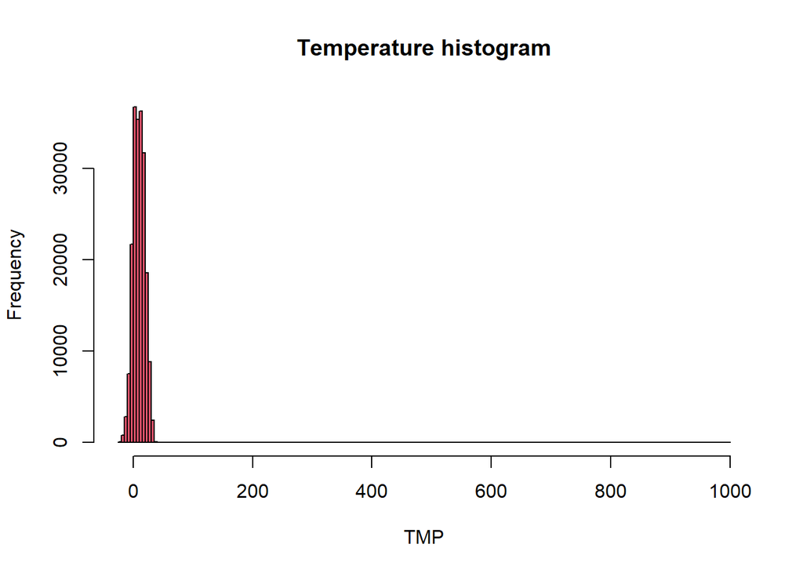

```r
hist(mandatory_data$TMP,
  xlab = "TMP",
  main = "Temperature histogram",
  breaks = sqrt(nrow(mandatory_data)/2),
  col = 2
)
```

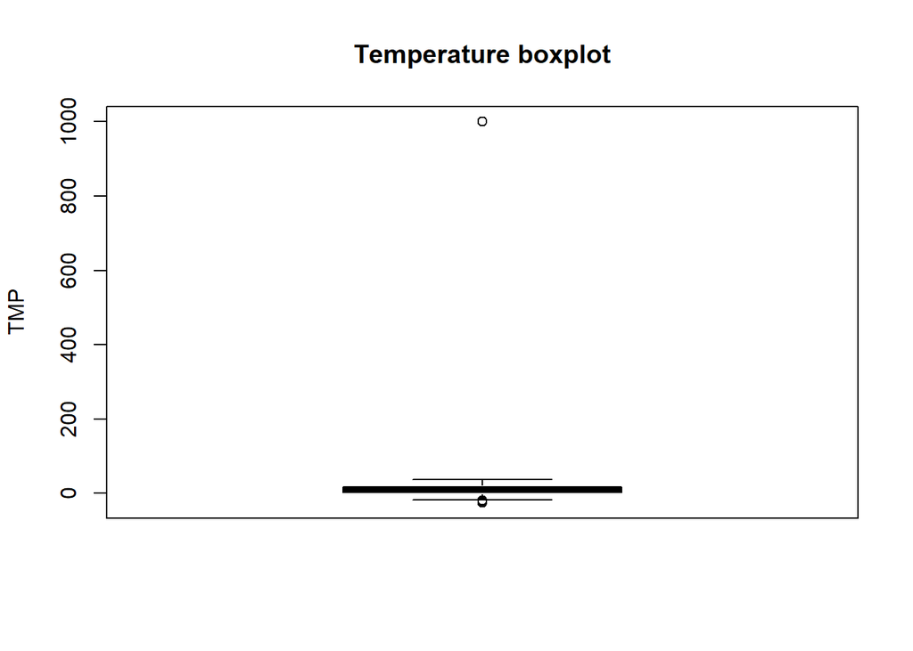

```r
boxplot(mandatory_data$TMP, col = 2, ylab = "TMP", main = "Temperature boxplot")
```

```r
boxplot.stats(mandatory_data$TMP)$out
```

```
##   [1] 999.9 -19.0 -18.8 -19.0 -19.4 -20.0 -20.2 -21.0 -19.9 -21.0 -18.5 -19.0
##  [13] -19.1 -19.0 -19.1 -19.0 -19.1 -19.0 -20.3 -20.0 -20.4 -20.0 -18.5 -18.3
##  [25] -18.6 -19.0 -18.7 -19.0 -18.7 -19.0 -19.0 -18.4 -19.0 -19.0 -18.3 -19.0
##  [37] -18.7 -19.0 -19.0 -19.0 -19.0 -19.0 999.9 -19.0 -19.0 -20.0 -20.0 -20.0
##  [49] -21.0 -22.0 -22.0 -22.0 -23.0 -23.0 -23.0 -24.0 -24.0 -24.0 -24.0 -25.0
##  [61] -24.0 -24.0 -25.0 -25.0 -25.0 -25.0 -24.0 -22.0 -21.0 -19.0 -19.0 -19.0
##  [73] -20.0 -20.0 -20.0 -20.0 -20.0 -21.0 -21.0 -21.0 -21.0 -21.0 -22.0 -22.0
##  [85] -22.0 -22.0 -22.0 -22.0 -21.0 -22.0 -21.0 -21.0 -21.0 -22.0 -21.0 -22.0
##  [97] -20.0 -19.0 -19.0 -19.0 -19.0 -19.0 -19.0 -19.0 -19.0 -19.0 -19.0 -19.0
## [109] -19.0 -20.0 -20.0 -20.0 -20.0 -20.0 -20.0 -19.0 -19.0 -19.0 -19.0 -19.0
## [121] -20.0 -20.0 -20.0 -21.0 -21.0 -20.0 -21.0 -21.0 -20.0 -21.0 -20.0 -21.0
## [133] -20.0 -21.0 -21.0 -20.0 -20.0 -19.0 -19.0 -19.0 -20.0 -20.0 -19.0 -20.0
## [145] -19.0 -19.0 -19.0 -20.0 -19.0 -20.0 -19.0 -19.0 -19.0 -19.0 -19.0 -19.0
## [157] 999.9
```

### Wind angle

```r
summary(mandatory_data$WND_ANGLE)
```

```
##    Min. 1st Qu.  Median    Mean 3rd Qu.    Max.    NA's
##    10.0    60.0   200.0   184.2   290.0   360.0  106370
```

```r
mandatory_data['WND_ANGLE'] %>% profiling_num()
```

```
##    variable     mean  std_dev variation_coef p_01 p_05 p_25 p_50 p_75 p_95 p_99
## 1 WND_ANGLE 184.2069 118.4567      0.6430632   10   10   60  200  290  360  360
##      skewness kurtosis iqr  range_98  range_80
## 1 -0.08690638 1.632475 230 [10, 360] [20, 350]
```

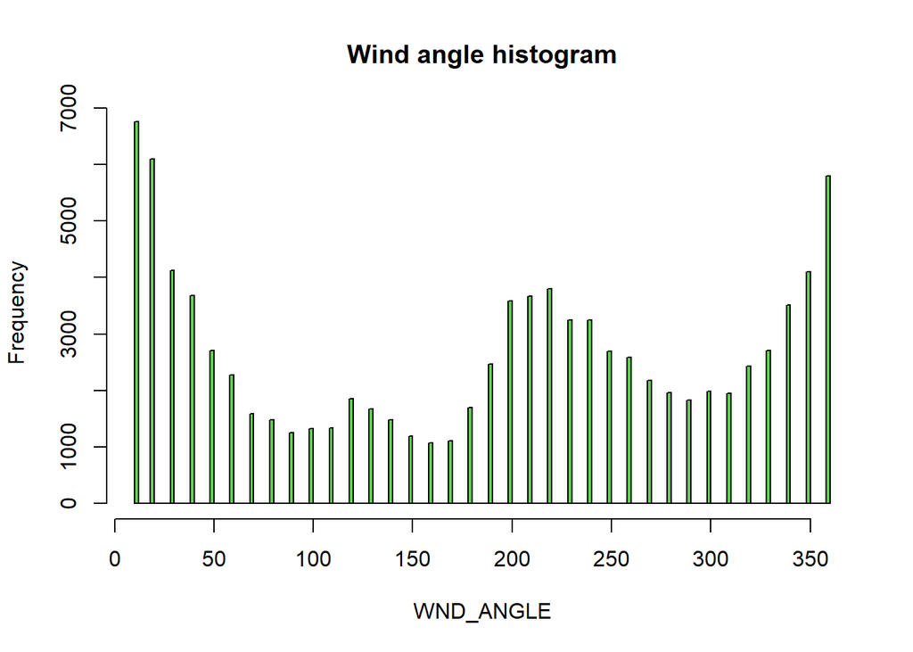

```r
hist(mandatory_data$WND_ANGLE,
  xlab = "WND_ANGLE",
  main = "Wind angle histogram",
  breaks = sqrt(nrow(mandatory_data)/4),
  col = 3
)
```

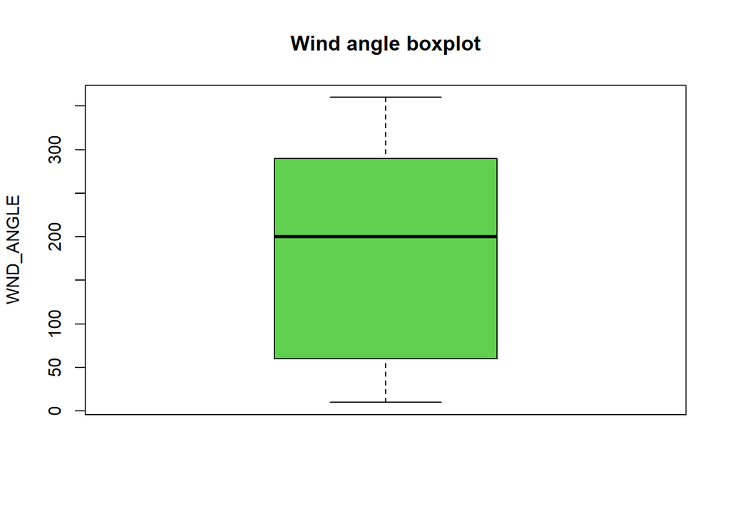

```r
boxplot(mandatory_data$WND_ANGLE, col = 3, ylab = "WND_ANGLE", main = "Wind angle boxplot")
```

```r
boxplot.stats(mandatory_data$WND_ANGLE)$out
```

```
## numeric(0)
```

### Wind speed

```r
summary(mandatory_data$WND_SPEED)
```

```
##    Min. 1st Qu.  Median    Mean 3rd Qu.    Max.    NA's
##   0.000   0.500   1.000   1.833   2.600  16.000   17149
```

```r
mandatory_data['WND_SPEED'] %>% profiling_num()
```

```
##    variable     mean std_dev variation_coef p_01 p_05 p_25 p_50 p_75 p_95 p_99
## 1 WND_SPEED 1.833376 1.81251      0.9886188    0    0  0.5    1  2.6  5.7    8
##   skewness kurtosis iqr range_98 range_80
## 1 1.580382 6.201441 2.1   [0, 8] [0, 4.1]
```

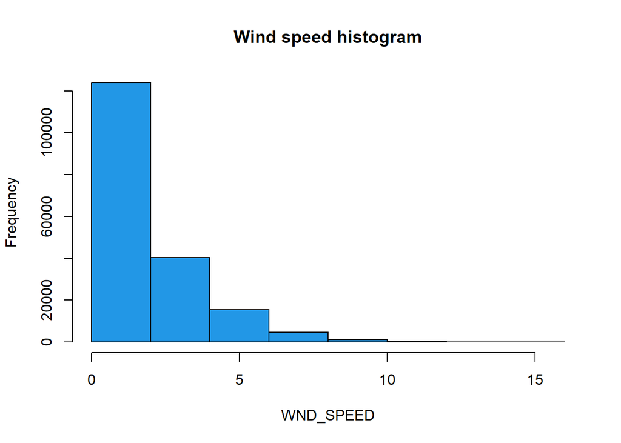

```r
hist(mandatory_data$WND_SPEED,
  xlab = "WND_SPEED",
  main = "Wind speed histogram",
  breaks = 10,
  col = 4
)
```

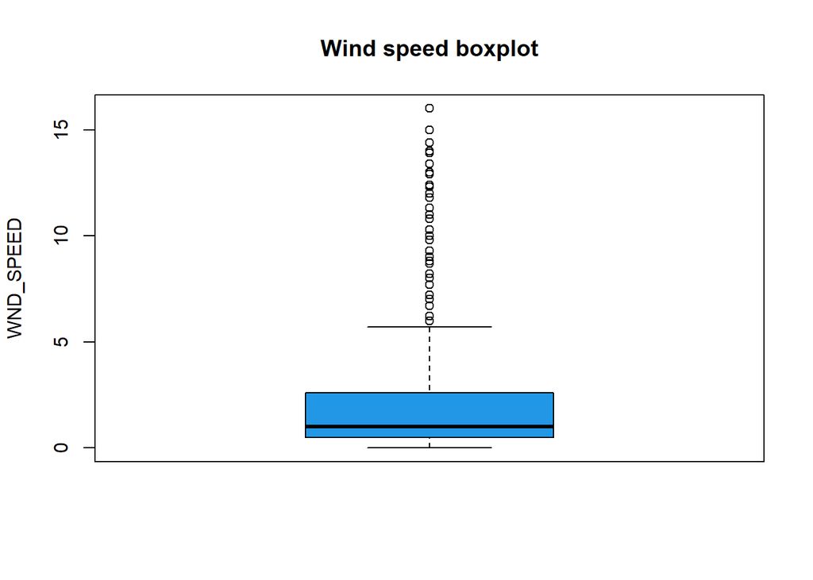

```r
boxplot(mandatory_data$WND_SPEED, col = 4, ylab = "WND_SPEED", main = "Wind speed boxplot")
```

```r
boxplot.stats(mandatory_data$WND_SPEED)$out
```

[output not shown]

[output cut: 543 more lines]

### Visibility

```r
summary(mandatory_data$VIS)
```

```
##    Min. 1st Qu.  Median    Mean 3rd Qu.    Max.
##       0    9900   10000  138776   25000  999999
```

```r
mandatory_data['VIS'] %>% profiling_num()
```

```
##   variable     mean std_dev variation_coef p_01 p_05 p_25  p_50  p_75   p_95
## 1      VIS 138776.3  328278        2.36552  100 1000 9900 10000 25000 999999
##     p_99 skewness kurtosis   iqr      range_98       range_80
## 1 999999 2.239514 6.023618 15100 [100, 999999] [3000, 999999]
```

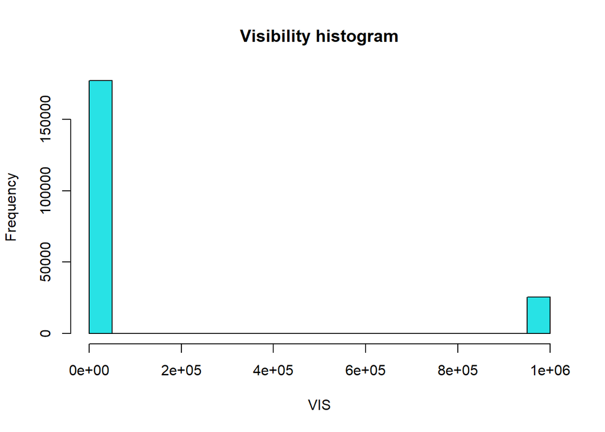

```r
hist(mandatory_data$VIS,
  xlab = "VIS",
  main = "Visibility histogram",
  breaks = 30,
  col = 5
)
```

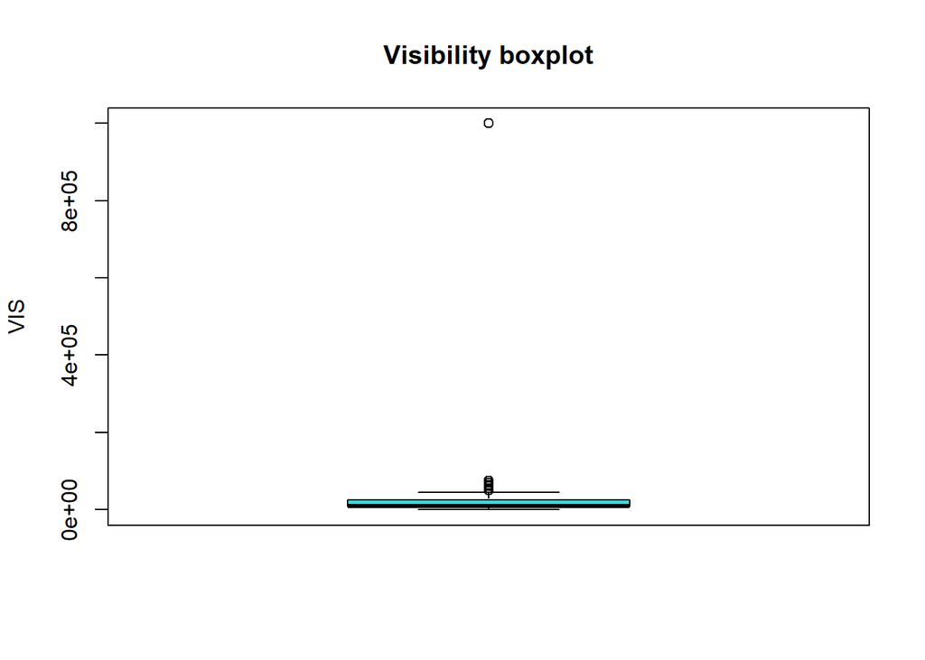

```r
boxplot(mandatory_data$VIS, col = 5, ylab = "VIS", main = "Visibility boxplot")
```

```r
boxplot.stats(mandatory_data$VIS)$out
```

[output not shown]

[output cut: 2801 more lines]

### Pressure

```r
summary(mandatory_data$SLP)
```

```
##    Min. 1st Qu.  Median    Mean 3rd Qu.    Max.    NA's
##     975    1012    1017    1017    1022    1048  120723
```

```r
mandatory_data['SLP'] %>% profiling_num()
```

```
##   variable     mean  std_dev variation_coef  p_01   p_05 p_25   p_50   p_75
## 1      SLP 1017.057 7.955223    0.007821809 997.6 1004.8 1012 1016.6 1021.9
##     p_95     p_99   skewness kurtosis iqr          range_98         range_80
## 1 1031.1 1036.474 0.08247437 3.564882 9.9 [997.6, 1036.474] [1007.7, 1027.6]
```

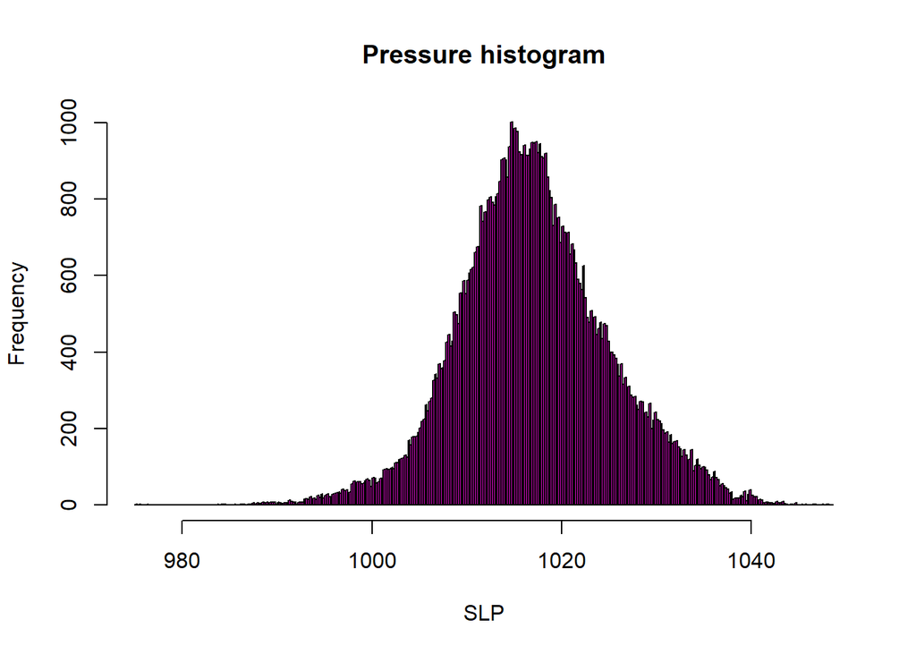

```r
hist(mandatory_data$SLP,
  xlab = "SLP",
  main = "Pressure histogram",
  breaks = sqrt(nrow(mandatory_data)/2),
  col = 6
)
```

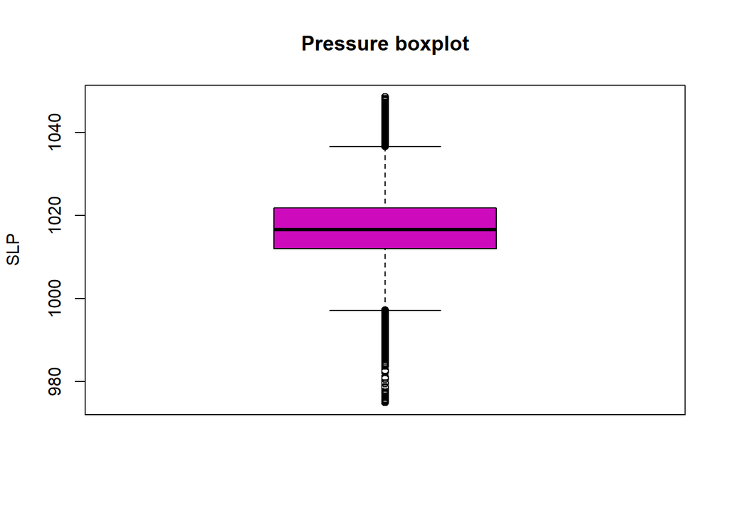

```r
boxplot(mandatory_data$SLP, col = 6, ylab = "SLP", main = "Pressure boxplot")
```

```r
boxplot.stats(mandatory_data$SLP)$out
```

[output not shown]

[output cut: 133 more lines]

### Ceiling

```r
summary(mandatory_data$CIG)
```

```
##    Min. 1st Qu.  Median    Mean 3rd Qu.    Max.    NA's
##       0     660    1463    5935    4200   22000   72465
```

```r
mandatory_data['CIG'] %>% profiling_num()
```

```
##   variable     mean  std_dev variation_coef p_01 p_05 p_25 p_50 p_75  p_95
## 1      CIG 5935.329 8612.568       1.451068   30   60  660 1463 4200 22000
##    p_99 skewness kurtosis  iqr    range_98     range_80
## 1 22000 1.288541 2.743948 3540 [30, 22000] [152, 22000]
```

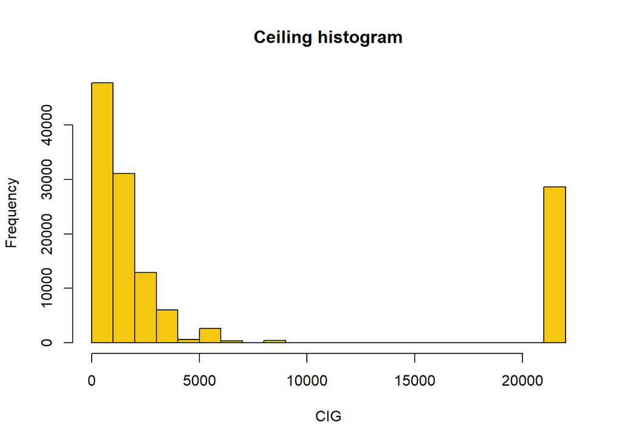

```r
hist(mandatory_data$CIG,
  xlab = "CIG",
  main = "Ceiling histogram",
  breaks = 20,
  col = 7
)
```

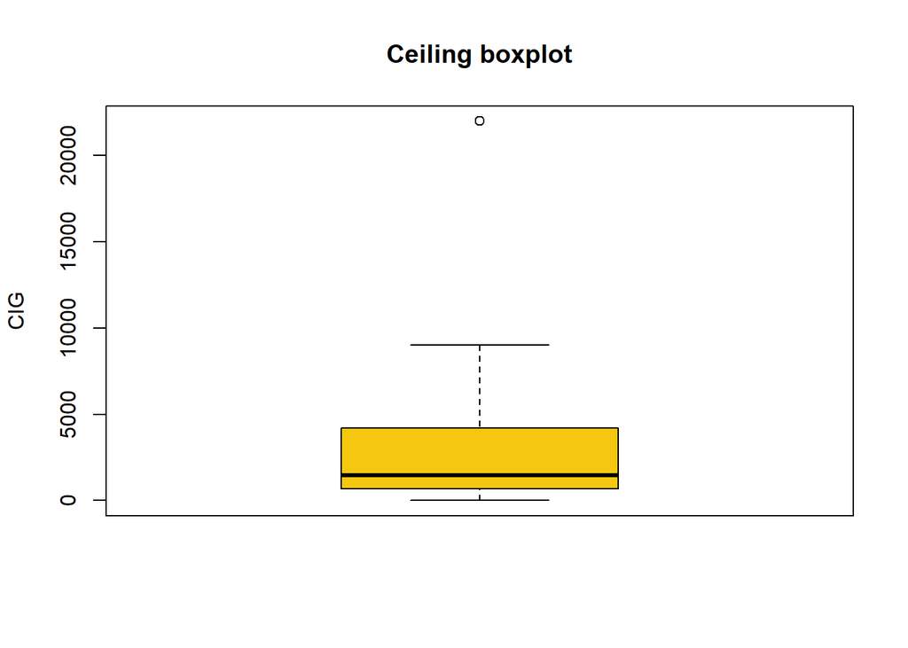

```r
boxplot(mandatory_data$CIG, col = 7, ylab = "CIG", main = "Ceiling boxplot")
```

```r
boxplot.stats(mandatory_data$CIG)$out
```

[output not shown]

[output cut: 2374 more lines]

```r
corr <- cor(mandatory_data[,3:8], use = "na.or.complete")
```